# Lab 7: Heart Attack

Author

Sydney Thompson

Github Link: https://github.com/orsydney003/GSB_S544/tree/main/Lab7

# The Data

## In this lab, we will use medical data to predict the likelihood of a person experiencing an exercise-induced heart attack.

## Our dataset consists of clinical data from patients who entered the hospital complaining of chest pain (“angina”) during exercise. The information collected includes:

- `age` : Age of the patient
- `sex` : Sex of the patient
- `cp` : Chest Pain type
- Value 0: asymptomatic
- Value 1: typical angina
- Value 2: atypical angina
- Value 3: non-anginal pain
- `trtbps` : resting blood pressure (in mm Hg)
- `chol` : cholesterol in mg/dl fetched via BMI sensor
- `restecg` : resting electrocardiographic results
- Value 0: normal
- Value 1: having ST-T wave abnormality (T wave inversions and/or ST elevation or depression of > 0.05 mV)
- Value 2: showing probable or definite left ventricular hypertrophy by Estes’ criteria
- `thalach` : maximum heart rate achieved during exercise
- `output` : the doctor’s diagnosis of whether the patient is at risk for a heart attack
- 0 = not at risk of heart attack
- 1 = at risk of heart attack

Although it is not a formal question on this assignment, you should begin by reading in the dataset and briefly exploring and summarizing the data, and by adjusting any variables that need cleaning.

```python
import pandas as pd

ha = pd.read_csv("https://www.dropbox.com/s/aohbr6yb9ifmc8w/heart_attack.csv?dl=1")
ha.head()
```

|  | age | sex | cp | trtbps | chol | restecg | thalach | output |
| --- | --- | --- | --- | --- | --- | --- | --- | --- |
| 0 | 63 | 1 | 3 | 145 | 233 | 0 | 150 | 1 |
| 1 | 37 | 1 | 2 | 130 | 250 | 1 | 187 | 1 |
| 2 | 56 | 1 | 1 | 120 | 236 | 1 | 178 | 1 |
| 3 | 57 | 0 | 0 | 120 | 354 | 1 | 163 | 1 |
| 4 | 57 | 1 | 0 | 140 | 192 | 1 | 148 | 1 |

```python
# descriptive statistic summary
ha.describe()
```

|  | age | sex | cp | trtbps | chol | restecg | thalach | output |
| --- | --- | --- | --- | --- | --- | --- | --- | --- |
| count | 273.000000 | 273.000000 | 273.000000 | 273.000000 | 273.000000 | 273.000000 | 273.000000 | 273.000000 |
| mean | 54.347985 | 0.673993 | 0.974359 | 132.098901 | 246.860806 | 0.538462 | 149.446886 | 0.534799 |
| std | 9.163134 | 0.469611 | 1.030456 | 17.700358 | 52.569726 | 0.528059 | 23.240707 | 0.499704 |
| min | 29.000000 | 0.000000 | 0.000000 | 94.000000 | 126.000000 | 0.000000 | 71.000000 | 0.000000 |
| 25% | 47.000000 | 0.000000 | 0.000000 | 120.000000 | 211.000000 | 0.000000 | 133.000000 | 0.000000 |
| 50% | 56.000000 | 1.000000 | 1.000000 | 130.000000 | 240.000000 | 1.000000 | 152.000000 | 1.000000 |
| 75% | 61.000000 | 1.000000 | 2.000000 | 140.000000 | 275.000000 | 1.000000 | 166.000000 | 1.000000 |
| max | 77.000000 | 1.000000 | 3.000000 | 200.000000 | 564.000000 | 2.000000 | 202.000000 | 1.000000 |

```python
# information about the data
ha.info()
```

```
<class 'pandas.core.frame.DataFrame'>
RangeIndex: 273 entries, 0 to 272
Data columns (total 8 columns):
 #   Column   Non-Null Count  Dtype
---  ------   --------------  -----
 0   age      273 non-null    int64
 1   sex      273 non-null    int64
 2   cp       273 non-null    int64
 3   trtbps   273 non-null    int64
 4   chol     273 non-null    int64
 5   restecg  273 non-null    int64
 6   thalach  273 non-null    int64
 7   output   273 non-null    int64
dtypes: int64(8)
memory usage: 17.2 KB
```

```python
# checking to see if there are any null values
ha.isnull().sum()
```

```
age        0
sex        0
cp         0
trtbps     0
chol       0
restecg    0
thalach    0
output     0
dtype: int64
```

```python
# output values
# 0 = not at risk for heart disease
# 1 = at risk for heart disease
ha['output'].value_counts()
```

```
output
1    146
0    127
Name: count, dtype: int64
```

```python
# sex values
# 0 = female
# 1 = male
ha['sex'].value_counts()
```

```
sex
1    184
0     89
Name: count, dtype: int64
```

# Part One: Fitting Models

This section asks you to create a final best model for each of the model types studied this week. For each, you should:

Find the best model based on ROC AUC for predicting the target variable

Report the (cross-validated!) ROC AUC metric. Fit the final model. Output a confusion matrix; that is, the counts of how many observations fell into each predicted class for each true class.

(Where applicable) Interpret the coefficients and/or estimates produced by the model fit.

You should certainly try multiple model pipelines to find the best model. You do not need to include the output for every attempted model, but you should describe all of the models explored. You should include any hyperparameter tuning steps in your writeup as well.

```python
import numpy as np

from sklearn.model_selection import StratifiedKFold, GridSearchCV, cross_val_predict
from sklearn.preprocessing import StandardScaler, OneHotEncoder
from sklearn.pipeline import Pipeline
from sklearn.compose import ColumnTransformer
from sklearn.metrics import confusion_matrix, roc_curve, auc, roc_auc_score, recall_score, precision_score
from sklearn.neighbors import KNeighborsClassifier
from sklearn.linear_model import LogisticRegression
from sklearn.tree import DecisionTreeClassifier

from plotnine import *
```

```python
X = ha.drop(['output'], axis = 1)
y = ha['output']

# column transformer
preprocessor = ColumnTransformer(
    transformers=[
        ('num', StandardScaler(), ["age", "trtbps", "chol", "thalach"]),
        ('cat', OneHotEncoder(handle_unknown='ignore'), ["sex", "cp", "restecg"])
    ],
    remainder='passthrough'
)
```

# Q1: KNN

```python
# Q1: KNN

knn_pipe = Pipeline([
    ('preprocessor', preprocessor),
    ('knn', KNeighborsClassifier())
])

cv = StratifiedKFold(n_splits = 5, shuffle = True, random_state=42)

param_grid = {
    'knn__n_neighbors': [5, 10, 15, 20]}

gs_knn = GridSearchCV(knn_pipe, param_grid, cv = cv, scoring = 'roc_auc')
gs_knn.fit(X, y)

print("Best KNN ROC-AUC CV:\n", gs_knn.best_score_)

print("Best KNN Hyperparameter:\n", gs_knn.best_params_)

knn_predict = gs_knn.best_estimator_.predict(X)

# confusion matrix
print("KNN Confusion Matrix:\n", confusion_matrix(y, knn_predict))

# ROC AUC - in sample ROC (not accurate) - aprrox 0.83 -> commented out
# print("ROC AUC:", roc_auc_score(y, knn_proba))
```

```
Best KNN ROC-AUC CV:
 0.8271763041556145
Best KNN Hyperparameter:
 {'knn__n_neighbors': 10}
KNN Confusion Matrix:
 [[106  21]
 [ 43 103]]
```

Best KNN ROC-AUC CV: 0.8271763041556145

Best Hyperparameter: {’knn__n_neighbors’: 10}

KNN Confusion Matrix: [[106 21] [ 43 103]]

# Q2: Logistic Regression

```python
# Q2: Logisitic Regression

log_reg_pipe = Pipeline([
    ('preprocessor', preprocessor),
    ('log_reg', LogisticRegression(max_iter=1000))
])

param_grid = {'log_reg__C': [0.01, 0.1, 1, 10, 100, 1000]}

gs_log_reg = GridSearchCV(log_reg_pipe, param_grid, cv=cv, scoring = 'roc_auc')
gs_log_reg.fit(X, y)

print("Best Logistic Regression ROC-AUC CV:\n", gs_log_reg.best_score_)

print("Best Hyperparameter:\n", gs_log_reg.best_params_)

log_reg_predict = gs_log_reg.best_estimator_.predict(X)

# confusion matrix
print("Confusion Matrix Logistic Regression:\n", confusion_matrix(y, log_reg_predict))

# ROC AUC - in sample ROC-AUC (not accurate) - approx 0.86 -> commented out
# print("ROC AUC:", roc_auc_score(y, log_reg_proba))
```

```
Best Logistic Regression ROC-AUC CV:
 0.8568063660477453
Best Hyperparameter:
 {'log_reg__C': 1}
Confusion Matrix Logistic Regression:
 [[ 96  31]
 [ 24 122]]
```

Best Logistic Regression ROC-AUC CV: 0.8568063660477453

Best Hyperparameter: {’log_reg__C’: 1}

Confusion Matrix Logistic Regression: [[ 96 31] [ 24 122]]

```python
## Coefficient Interpretations
preprocessor = gs_log_reg.best_estimator_.named_steps['preprocessor']
numeric_vars = ["age", "trtbps", "chol", "thalach"]
categorical_vars = preprocessor.named_transformers_['cat']
categorical_fts = categorical_vars.get_feature_names_out(["sex", "cp", "restecg"])

all_vars = list(numeric_vars) + list(categorical_fts)

coefs_log_reg = gs_log_reg.best_estimator_['log_reg'].coef_[0]
coef_df_log_reg = pd.DataFrame({
    'feature': all_vars,
    'coef': coefs_log_reg,
    'odds_ratio': np.exp(coefs_log_reg)
}).sort_values('odds_ratio', ascending = False)

coef_df_log_reg.head()
```

|  | feature | coef | odds_ratio |
| --- | --- | --- | --- |
| 4 | sex_0 | 0.995994 | 2.707415 |
| 3 | thalach | 0.761459 | 2.141399 |
| 7 | cp_1 | 0.611635 | 1.843444 |
| 8 | cp_2 | 0.483018 | 1.620959 |
| 9 | cp_3 | 0.310153 | 1.363634 |

This logistic regression model suggests that certain predictors increase the risk of a heart attack occurring. For example, positive values (based on the coefficients outputted) show that these factors increase the odds of an individual having a heart attack. Negative values show the opposite effect: the odds are decreased.

# Q3: Decision Tree

```python
# Q3: Decision Tree

decision_tree_pipe = Pipeline([
    ('preprocessor', preprocessor),
    ('decision_tree', DecisionTreeClassifier(random_state=42))
])

# looked up other parameters to tune the decision tree pipeline
param_grid = {
    'decision_tree__max_depth': [3, 5, 8, None],
    'decision_tree__min_samples_leaf': [1, 5, 10, 20],
    'decision_tree__ccp_alpha': [0.0, 0.001, 0.01]
}

gs_dtree = GridSearchCV(decision_tree_pipe, param_grid, cv = cv, scoring = 'roc_auc')
gs_dtree.fit(X, y)

print("Best Decision Tree ROC-AUC CV:\n", gs_dtree.best_score_)
print("Best Hyperparameters:\n", gs_dtree.best_params_)

dt_predict = gs_dtree.best_estimator_.predict(X)

# confusion matrix
print("Confusion Matrix Decision Tree:\n", confusion_matrix(y, dt_predict))

# ROC AUC - in sample (not accurate) - approx 0.94
#print("ROC AUC:", roc_auc_score(y, dt_proba))
```

```
Best Decision Tree ROC-AUC CV:
 0.8220251105216623
Best Hyperparameters:
 {'decision_tree__ccp_alpha': 0.001, 'decision_tree__max_depth': 5, 'decision_tree__min_samples_leaf': 10}
Confusion Matrix Decision Tree:
 [[107  20]
 [ 30 116]]
```

Best Decision Tree ROC-AUC CV: 0.8220251105216623

Best Hyperparameters: {’decision_tree__ccp_alpha’: 0.001, ’decision_tree__max_depth’: 5, ’decision_tree__min_samples_leaf’: 10}

Confusion Matrix Decision Tree: [[107 20] [ 30 116]]

```python
# Feature Importance
tree_features = gs_dtree.best_estimator_['decision_tree']
important_features = pd.DataFrame({'feature': all_vars, 'importance': tree_features.feature_importances_}).sort_values('importance', ascending = False)
important_features.head()
```

|  | feature | importance |
| --- | --- | --- |
| 6 | cp_0 | 0.504280 |
| 0 | age | 0.151758 |
| 3 | thalach | 0.100803 |
| 5 | sex_1 | 0.093254 |
| 2 | chol | 0.079491 |

The decision tree model was able to capture interactions between predictors for heart attacks; however, this model might be overfitting the data (based on the in ROC AUC score).

# Q4: Interpretation

# Which predictors were most important to predicting heart attack risk?

For the decision tree model, the most important predictors were `cp_0` (asymptomatic) and `age`. The variables with the largest feature importance scores influence how the tree is classified. This also impacts how the tree is split.

# Q5: ROC Curve

Plot the ROC Curve for your three models above.

```python
# Q5 Plot

# prediction probabilities
proba_cv_knn = cross_val_predict(gs_knn.best_estimator_, X, y, cv = 5, method = 'predict_proba')[:,1]
proba_cv_log = cross_val_predict(gs_log_reg.best_estimator_, X, y, cv = 5, method = 'predict_proba')[:,1]
proba_cv_dt = cross_val_predict(gs_dtree.best_estimator_, X, y, cv = 5, method = 'predict_proba')[:,1]

# calculating ROC curves for each model
# function for roc curves (false positive + true positive rates)
fpr_knn, tpr_knn, _ = roc_curve(y, proba_cv_knn)
fpr_log_reg, tpr_log_reg, _ = roc_curve(y, proba_cv_log)
fpr_dtree, tpr_dtree, _ = roc_curve(y, proba_cv_dt)

# creating DF for plotnine
roc_df = pd.DataFrame({
    'fpr': list(fpr_knn) + list(fpr_log_reg) + list(fpr_dtree),
    'tpr': list(tpr_knn) + list(tpr_log_reg) + list(tpr_dtree),
    'model': (['KNN'] * len(fpr_knn)) + (['Logistic Regression'] * len(fpr_log_reg)) + (['Decision Tree'] * len(fpr_dtree))
})
```

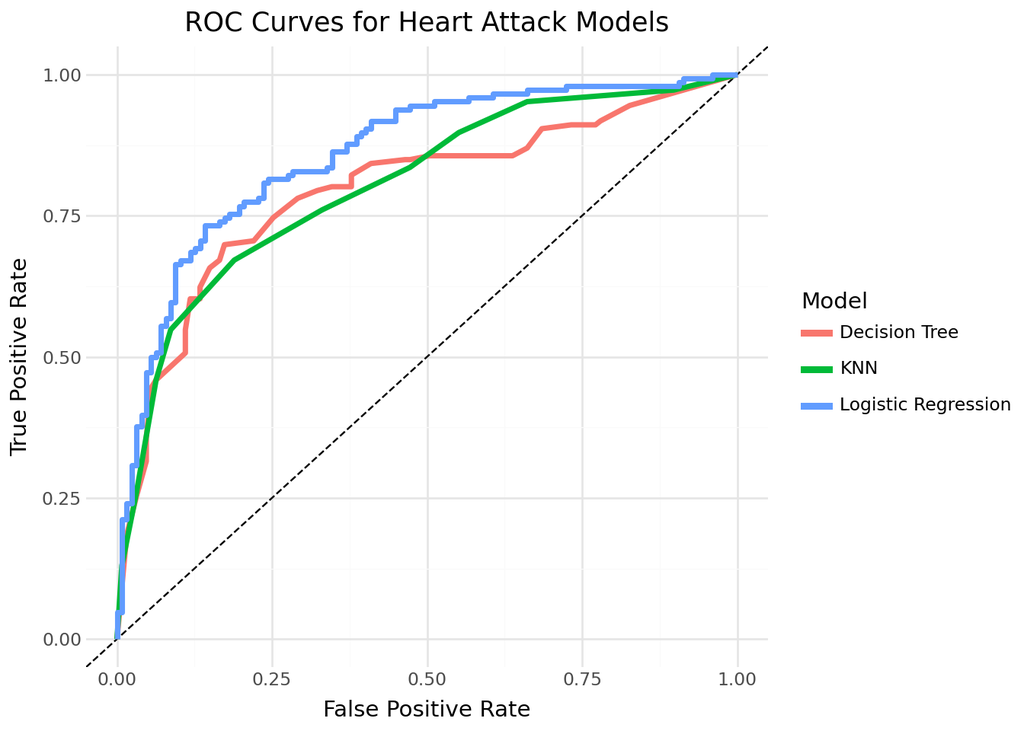

```python
# ROC curve plot
(
    ggplot(roc_df, aes(x='fpr', y='tpr', color='model'))
    + geom_abline(slope = 1, linetype = "dashed")
    + geom_line(size=1.5)
    + labs(x="False Positive Rate", y="True Positive Rate", title="ROC Curves for Heart Attack Models", color="Model")
    + theme_minimal()
)
```

This ROC curve plot is comparing the true positive and false positive rates for all three models. Based on this plot, the logistic regression model has the highest curve. It seems to be the best for predicting if an individual is at risk for heart disease. The decision tree model looks strong only on the training data.

# Part Two: Metrics

Consider the following metrics:

True Positive Rate or Recall or Sensitivity = Of the observations that are truly Class A, how many were predicted to be Class A?

Precision or Positive Predictive Value = Of all the observations classified as Class A, how many of them were truly from Class A?

True Negative Rate or Specificity or Negative Predictive Value = Of all the observations classified as NOT Class A, how many were truly NOT Class A?

Compute each of these metrics (cross-validated) for your three models (KNN, Logistic Regression, and Decision Tree) in Part One.

```python
# KNN
y_knn_cv = cross_val_predict(gs_knn.best_estimator_, X, y, cv = 5)

cm_knn = confusion_matrix(y, y_knn_cv)
recall_knn = recall_score(y, y_knn_cv)
precision_knn = precision_score(y, y_knn_cv)

# positions of the confusion matrix based on classes
tn = cm_knn[0, 0]
fp = cm_knn[0, 1]
fn = cm_knn[1, 0]
tp = cm_knn[1, 1]

specificity_knn = tn / (tn + fp)

print("KNN Confusion Matrix:\n", cm_knn)
print("KNN Recall (Sensitivity):\n", recall_knn)
print("KNN Precision:\n", precision_knn)
print("KNN Specificity:\n", specificity_knn)
```

```
KNN Confusion Matrix:
 [[103  24]
 [ 48  98]]
KNN Recall (Sensitivity):
 0.6712328767123288
KNN Precision:
 0.8032786885245902
KNN Specificity:
 0.8110236220472441
```

KNN Confusion Matrix: [[103 24] [ 48 98]]

KNN Recall (Sensitivity): 0.6712328767123288

KNN Precision: 0.8032786885245902

KNN Specificity: 0.8110236220472441

```python
# Logistic Regression

y_log_reg_cv = cross_val_predict(gs_log_reg.best_estimator_, X, y, cv=5)
cm_log_reg = confusion_matrix(y, y_log_reg_cv)
recall_log_reg = recall_score(y, y_log_reg_cv)
precision_log_reg = precision_score(y, y_log_reg_cv)

# positions of the confusion matrix based on classes
tn = cm_log_reg[0, 0]
fp = cm_log_reg[0, 1]
fn = cm_log_reg[1, 0]
tp = cm_log_reg[1, 1]

specificity_log_reg = tn / (tn + fp)

print("Logistic Regression Confusion Matrix:\n", cm_log_reg)
print("Logistic Regression Recall (Sensitivity):\n", recall_log_reg)
print("Logistic Regression Precision:\n", precision_log_reg)
print("Logistic Regression Specificity:\n", specificity_log_reg)
```

```
Logistic Regression Confusion Matrix:
 [[ 96  31]
 [ 27 119]]
Logistic Regression Recall (Sensitivity):
 0.815068493150685
Logistic Regression Precision:
 0.7933333333333333
Logistic Regression Specificity:
 0.7559055118110236
```

Logistic Regression Confusion Matrix: [[ 96 31] [ 27 119]]

Logistic Regression Recall (Sensitivity): 0.815068493150685

Logistic Regression Precision: 0.7933333333333333

Logistic Regression Specificity: 0.7559055118110236

```python
# Decision Tree
y_dt_cv = cross_val_predict(gs_dtree.best_estimator_, X, y, cv=5)
cm_dt = confusion_matrix(y, y_dt_cv)
recall_dt = recall_score(y, y_dt_cv)
precision_dt = precision_score(y, y_dt_cv)

# positions of the confusion matrix based on classes
tn = cm_dt[0, 0]
fp = cm_dt[0, 1]
fn = cm_dt[1, 0]
tp = cm_dt[1, 1]

specificity_dt = tn / (tn + fp)
print("Decision Tree Confusion Matrix\n", cm_dt)
print("Decision Tree Recall (Sensitivity):\n", recall_dt)
print("Decision Tree Precision:\n", precision_dt)
print("Decision Tree Specificity:\n", specificity_dt)
```

```
Decision Tree Confusion Matrix
 [[ 90  37]
 [ 32 114]]
Decision Tree Recall (Sensitivity):
 0.7808219178082192
Decision Tree Precision:
 0.7549668874172185
Decision Tree Specificity:
 0.7086614173228346
```

Decision Tree Confusion Matrix [[ 90 37] [ 32 114]]

Decision Tree Recall (Sensitivity): 0.7808219178082192

Decision Tree Precision: 0.7549668874172185

Decision Tree Specificity: 0.7086614173228346

# Part Three: Discussion

Suppose you have been hired by a hospital to create classification models for heart attack risk.

#The following questions give a possible scenario for why the hospital is interested in these models. For each one, discuss: - Which metric(s) you would use for model selection and why. - Which of your final models (Part One Q1-3) you would recommend to the hospital, and why. - What score you should expect for your chosen metric(s) using your chosen model to predict future observations.

# Q1: The hospital faces severe lawsuits if they deem a patient to be low risk, and that patient later experiences a heart attack.

In this scenario, recall is the key metric: we want to prioritize minimizing false negatives. The best model would be the Logistic Regression Model. It has the highest recall rate. If the hospital wants to prevent facing severe lawsuits, it’s better if they misdiagnose a patient rather than miss someone who is at risk for heart disease. The recall rate for this model is approximately 0.8151, and the precision is 0.7933.

# Q2: The hospital is overfull, and wants to only use bed space for patients most in need of monitoring due to heart attack risk.

In this scenario, precision would be the key metric because the hospital wants to minimize false positives. They don’t want to admit too many people. The best model would be the KNN (K-nearest neighbors) because it has the highest precision rate. This is because the hospital wants to save their resources and monitor those who really need their help. The precision rate for this model is approximately 0.8032.

# Q3: The hospital is studying root causes of heart attacks, and would like to understand which biological measures are associated with heart attack risk.

In this scenario, the key metrics are the coefficients and interpretability. I think either the logistic regression or decision tree models are best because they both show which clinical features contribute the most to heart disease. We can also look at each model’s ROC-AUC scores (0.856 for the logistic model and 0.822 for the decision tree model). Based on the ROC-AUC score, I would choose the Logistic Regression model.

# Q4: The hospital is training a new batch of doctors, and they would like to compare the diagnoses of these doctors to the predictions given by the algorithm to measure the ability of new doctors to diagnose patients.

In this scenario, the key metric would be Cohen’s Kappa (agreement beyond chance). The best model is logistic regression because it aligns with the clinical features of the dataset. It makes it easy to compare between the model and clinicians and also interpret any discrepancies. For the expected performance, we would look at the ROC-AUC (approximately 0.856).

# Part Four: Validation

Before sharing the dataset with you, I set aside a random 10% of the observations to serve as a final validation set.

```python
import pandas as pd
ha_validation = pd.read_csv("https://www.dropbox.com/s/jkwqdiyx6o6oad0/heart_attack_validation.csv?dl=1")
ha_validation.head()
```

|  | age | sex | cp | trtbps | chol | restecg | thalach | output |
| --- | --- | --- | --- | --- | --- | --- | --- | --- |
| 0 | 41 | 0 | 1 | 130 | 204 | 0 | 172 | 1 |
| 1 | 64 | 1 | 3 | 110 | 211 | 0 | 144 | 1 |
| 2 | 59 | 1 | 0 | 135 | 234 | 1 | 161 | 1 |
| 3 | 42 | 1 | 0 | 140 | 226 | 1 | 178 | 1 |
| 4 | 40 | 1 | 3 | 140 | 199 | 1 | 178 | 1 |

```python
# dataset dimensions
ha_validation.shape
```

```
(30, 8)
```

```python
# descriptive statistic summary on validation
ha_validation.describe()
```

|  | age | sex | cp | trtbps | chol | restecg | thalach | output |
| --- | --- | --- | --- | --- | --- | --- | --- | --- |
| count | 30.000000 | 30.000000 | 30.000000 | 30.000000 | 30.000000 | 30.000000 | 30.000000 | 30.000000 |
| mean | 54.533333 | 0.766667 | 0.900000 | 127.300000 | 240.833333 | 0.433333 | 151.466667 | 0.633333 |
| std | 8.451620 | 0.430183 | 1.061879 | 15.592107 | 44.962117 | 0.504007 | 19.842020 | 0.490133 |
| min | 40.000000 | 0.000000 | 0.000000 | 100.000000 | 131.000000 | 0.000000 | 111.000000 | 0.000000 |
| 25% | 48.000000 | 1.000000 | 0.000000 | 113.500000 | 205.750000 | 0.000000 | 143.250000 | 0.000000 |
| 50% | 54.500000 | 1.000000 | 0.500000 | 130.000000 | 245.000000 | 0.000000 | 155.000000 | 1.000000 |
| 75% | 59.000000 | 1.000000 | 2.000000 | 139.500000 | 272.500000 | 1.000000 | 162.000000 | 1.000000 |
| max | 71.000000 | 1.000000 | 3.000000 | 160.000000 | 330.000000 | 1.000000 | 182.000000 | 1.000000 |

```python
# information about the validation dataset
ha_validation.info()
```

```
<class 'pandas.core.frame.DataFrame'>
RangeIndex: 30 entries, 0 to 29
Data columns (total 8 columns):
 #   Column   Non-Null Count  Dtype
---  ------   --------------  -----
 0   age      30 non-null     int64
 1   sex      30 non-null     int64
 2   cp       30 non-null     int64
 3   trtbps   30 non-null     int64
 4   chol     30 non-null     int64
 5   restecg  30 non-null     int64
 6   thalach  30 non-null     int64
 7   output   30 non-null     int64
dtypes: int64(8)
memory usage: 2.0 KB
```

```python
# output values
# 0 = not at risk for heart disease
# 1 = at risk for heart disease
ha_validation['output'].value_counts()
```

```
output
1    19
0    11
Name: count, dtype: int64
```

```python
# sex values
# 0 = female
# 1 = male
ha_validation['sex'].value_counts()
```

```
sex
1    23
0     7
Name: count, dtype: int64
```

Use each of your final models in Part One Q1-3, predict the target variable in the validation dataset.

For each, output a confusion matrix, and report the ROC AUC, the precision, and the recall.

Compare these values to the cross-validated estimates you reported in Part One and Part Two. Did our measure of model success turn out to be approximately correct for the validation data?

```python
X_val = ha_validation.drop(['output'], axis = 1)
y_val = ha_validation['output']
```

```python
from sklearn.metrics import confusion_matrix, roc_auc_score, recall_score, precision_score

# KNN
y_knn_pred = gs_knn.best_estimator_.predict(X_val)
y_knn_prob = gs_knn.best_estimator_.predict_proba(X_val)[:,1]
cm_knn = confusion_matrix(y_val, y_knn_pred)
recall_knn = recall_score(y_val, y_knn_pred)
precision_knn = precision_score(y_val, y_knn_pred)
rocauc_knn = roc_auc_score(y_val, y_knn_prob)

tn = cm_knn[0, 0]
fp = cm_knn[0, 1]

specificity_knn = tn / (tn + fp)
print("KNN Validation Confusion Matrix:\n", cm_knn)
print("KNN Validation ROC AUC:\n", rocauc_knn)
print("KNN Validation Recall (Sensitivity):\n", recall_knn)
print("KNN Validation Precision:\n", precision_knn)
print("KNN Validation Specificity:\n", specificity_knn)
```

```
KNN Validation Confusion Matrix:
 [[10  1]
 [ 9 10]]
KNN Validation ROC AUC:
 0.8133971291866028
KNN Validation Recall (Sensitivity):
 0.5263157894736842
KNN Validation Precision:
 0.9090909090909091
KNN Validation Specificity:
 0.9090909090909091
```

KNN Validation Confusion Matrix: [[10 1] [ 9 10]]

KNN Validation ROC AUC: 0.8133971291866028

KNN Validation Recall (Sensitivity): 0.5263157894736842

KNN Validation Precision: 0.9090909090909091

KNN Validation Specificity: 0.9090909090909091

```python
# Logistic Regression
y_log_reg_pred = gs_log_reg.best_estimator_.predict(X_val)
y_log_reg_prob = gs_log_reg.best_estimator_.predict_proba(X_val)[:,1]
cm_log_reg = confusion_matrix(y_val, y_log_reg_pred)
recall_log_reg = recall_score(y_val, y_log_reg_pred)
precision_log_reg = precision_score(y_val, y_log_reg_pred)
rocauc_log_reg = roc_auc_score(y_val, y_log_reg_prob)

tn = cm_log_reg[0, 0]
fp = cm_log_reg[0, 1]

specificity_log_reg = tn / (tn + fp)
print("Logistic Regression Validation Confusion Matrix:\n", cm_log_reg)
print("Logistic Regression Validation ROC AUC:\n", rocauc_log_reg)
print("Logistic Regression Validation Recall (Sensitivity):\n", recall_log_reg)
print("Logistic Regression Validation Precision:\n", precision_log_reg)
print("Logistic Regression Validation Specificity:\n", specificity_log_reg)
```

```
Logistic Regression Validation Confusion Matrix:
 [[ 9  2]
 [ 5 14]]
Logistic Regression Validation ROC AUC:
 0.8851674641148326
Logistic Regression Validation Recall (Sensitivity):
 0.7368421052631579
Logistic Regression Validation Precision:
 0.875
Logistic Regression Validation Specificity:
 0.8181818181818182
```

Logistic Regression Validation Confusion Matrix: [[ 9 2] [ 5 14]]

Logistic Regression Validation ROC AUC: 0.8851674641148326

Logistic Regression Validation Recall (Sensitivity): 0.7368421052631579

Logistic Regression Validation Precision: 0.875

Logistic Regression Validation Specificity: 0.8181818181818182

When comparing to Part 2 of this lab, the ROC AUC scores are very similar (the validation decision tree is slightly higher). However, the recall score is lower (0.7368 vs. 0.8150). In addition, both the validation precision score (0.875 vs. 0.7933) and specificity (0.818 vs. 0.755) is higher.

```python
# Decision Tree
y_dt_pred = gs_dtree.best_estimator_.predict(X_val)
y_dt_prob = gs_dtree.best_estimator_.predict_proba(X_val)[:,1]
cm_dt = confusion_matrix(y_val, y_dt_pred)
recall_dt = recall_score(y_val, y_dt_pred)
precision_dt = precision_score(y_val, y_dt_pred)
rocauc_dt = roc_auc_score(y_val, y_dt_prob)

tn = cm_dt[0, 0]
fp = cm_dt[0, 1]

specificity_dt = tn / (tn + fp)
print("Decision Tree Validation Confusion Matrix:\n", cm_dt)
print("Decision Tree Validation ROC AUC:\n", rocauc_dt)
print("Decision Tree Validation Recall (Sensitivity):\n", recall_dt)
print("Decision Tree Validation Precision:\n", precision_dt)
print("Decision Tree Validation Specificity:\n", specificity_dt)
```

```
Decision Tree Validation Confusion Matrix:
 [[ 9  2]
 [ 8 11]]
Decision Tree Validation ROC AUC:
 0.8349282296650717
Decision Tree Validation Recall (Sensitivity):
 0.5789473684210527
Decision Tree Validation Precision:
 0.8461538461538461
Decision Tree Validation Specificity:
 0.8181818181818182
```

Decision Tree Validation Confusion Matrix: [[ 9 2] [ 8 11]]

Decision Tree Validation ROC AUC: 0.8349282296650717

Decision Tree Validation Recall (Sensitivity): 0.5789473684210527

Decision Tree Validation Precision: 0.8461538461538461

Decision Tree Validation Specificity: 0.8181818181818182

When comparing to Part 2 of this lab, the ROC AUC scores are very similar (the validation decision tree is slightly higher). However, the recall score is lower (0.5789 vs. 0.7808). In addition, both the validation precision score (0.846 vs. 0.754) and specificity (0.818 vs. 0.708) is higher. It seems the model may be overfitting the dataset.

# Part Five: Cohen’s Kappa

Another common metric used in classification is Cohen’s Kappa.

Use online resources to research this measurement. Calculate it for the models from Part One, Q1-3, and discuss reasons or scenarios that would make us prefer to use this metric as our measure of model success. Do your conclusions from above change if you judge your models using Cohen’s Kappa instead? Does this make sense?

```python
from sklearn.metrics import cohen_kappa_score

kappa_knn = cohen_kappa_score(y, y_knn_cv)
kappa_knn
```

```
0.47639850825785834
```

```python
kappa_log_reg = cohen_kappa_score(y, y_log_reg_cv)
kappa_log_reg
```

```
0.5721465629053177
```

```python
kappa_dec_tree = cohen_kappa_score(y, y_dt_cv)
kappa_dec_tree
```

```
0.4907404904160696
```

Cohen’s Kappa measures the agreement between predicted and true labels, which is adjusted for chance.

In healthcare, it is useful for comparing human vs. model agreements. You could look at comparing other doctor predictions, hospital transfers, or regulatory/audit evaluations. These model predictions could tell us more about diagnostic consistency, training/label quality, how the model would perform on rare cases, and also how it complies with safety protocols.

Logistic Regression has the highest k; therefore, it is consistent with the parts above. It doesn’t change how I judge the models from above.